# Mercado de Capitais

21/10/2021

## Conteúdo do curso

- Unidade 1: Funcionamento dos mercados
  - Hipótese de mercado eficiente
  - Ambiente financeiro brasileiro
- Unidade 2: **Análise de investimentos em ações**
  - Um papo sobre Filosofia de Investimento
  - Análise Técnica
  - Anáslise Fundamentalista
- Unidade 3: Análise de portfolio de investimento

## Filosofia de Investimento

## Filosofia de Investimento

- Quem não gostaria de ser um investidor de sucesso?
- Quem não gostaria de ter um desempenho similar à investidores como Warren Buffet, George Soros, Peter Lynch?
- Qual a estratégia desses investidores? É possível replicar?

## Filosofia de Investimento

- Quem não gostaria de ser um investidor de sucesso?
- Quem não gostaria de ter um desempenho similar à investidores como Warren Buffet, George Soros, Peter Lynch?
- Qual a estratégia desses investidores? É possível replicar?

## Filosofia de Investimento

*“Para se ter sucesso com qualquer estratégia de investimento você precisa começar com uma **filosofia de investimento que seja consistente** na sua essência e esteja **alinhada** não só **com o mercado** que você decidiu investir mas também **com suas características invididuais.**”* Aswath Damodaran

[figure not shown]

## Definindo Filosofia de Investimento

Uma filosofia de investimento é muito mais amplo do que uma estratégia, é uma forma coerente de pensar e entender o mercado, como eles funcionam (e algumas vezes como não funcionam), e os tipos de erros que você acredita serem decorrentes do comportamento do investidor.

## Os Mercados e o Comportamento Humano

Não é que teoria economica financeira assuma que todos os investidores sejam racionais, mas sim a suposição de que as irracionalidades são aleatórias e se anulam.

Enquanto que no longo prazo essa suposição pode ser válida, no curto prazo pode não ser realista.

## Formas de Eficiência de Mercado (EM)

De acordo com a teoria da eficiência de mercado, na média os preços incorporam as informações existentes. Ou seja, mesmo que existam desvios esses são aleatórios e se anulam.

As três formas existentes de EM são:

1. Fraca: Todas as informações relacionadas aos preços passados já estão incorporadas no preço atual. Ou seja, é difícil encontrar consistemente oportunidades de investimentos apenas utilizando os preços passados, o que representa uma ideia que inviabiliza o suscesso de uma análise técnica.
2. Semi-forte: Todas as informações disponíveis já estão incorporadas no preço atual. Em outras palavras, é difícil encontrar consistemente oportunidades de investimentos utilizando informações disponíveis no mercado, o que em certa medida contradiz o que espera alguns usuários da análise fundamentalista.
3. Forte: Até as informações privilegiadas já estão incorporadas no preço atual.

## As preferências pessoais e a filosofia

Para entender como formar uma filosofia de investimento, é interessante ver como analistas definem uma estratégia para um determinado cliente:

- Passo 1: Entendendo o cliente
- Passo 2: Construindo o portfolio
- Passo 3: Avaliar a performance do porfolio. Investir é acima de tudo, focar em um único objetivo, que é ter o melhor retorno que você puder, dados suas preferências de risco.

## Categorizando Filosofias de Investimento

- Market Timing versus Seleção de Ativos
- Ativista versus Investimento Passivo
- Horizonte temporal

## Desenvolvendo uma Filosofia de Investimento

A filosofia de investimento que funciona para alguns investidores não funciona para outros. Logo não pode se ter uma filosofia de investimento que seja ideal para todos os investidores.

- Passo 1: Entender os fundamentos de Riscos e da avaliação de ativos (valuation).
- Passo 2: Desenvolver um ponto de vista sobre como os mercados funcionam e onde eles podem quebrar.
- Passo 3: Encontrar a filosofia que melhor se encaixe no seu perfil. O que considerar? Aversão ao risco, o tamanho do potfolio, o horizonte de tempo e o impacto dos impostos.

## Em resumo

- Uma filosofia de investimento representa um conjunto de crenças sobre como os investidores se comportam e como os mercados funcionam.
- Para ser um investidor de sucesso, é necessário não só considerar as evidências de mercado, mas também avaliar suas próprias forças e fraquezar para moldar a filosia de investimento que melhor se adeque a você.

## Análise Técnica e Fundamentalista

Próximo assunto…

## Análise Técnica e Fundamentalista

Duas técnicas muito usuais no mercado financeiro, mas que normalmente os investidores optam por usar apenas uma delas.

Perguntas interessantes:

- Estão de acordo com os estudos científicos?
- Os investidores são racionais?

## Análise Técnica

- Estuda o movimento dos preços dos ativos e o volume negociado.
- Por meio de indicadores técnicos e de padrões em gráficos.
- Comumente usado com um horizonte de curto prazo.

## Análise Fundamentalista

- Analisa aspectos financeiros e econômicos das empresas.
- Faz análise micro e macroeconômica.
- Também analisa dados quantitativos e qualitativos das empresas.
- Comumente usado com um horizonte de Médio e Longo Prazo.

## Mas dá para usar as duas técnicas?

Há investidores que utilizam as duas técnicas de forma complementar. Neste caso, a análise fundamentalista serve para identificar boas oportunidades de investimento no médio e longo prazo. Após a identificação de ações interessantes para investir, esses investidores utilizam análise técnica para identificar o melhor momento para comprar as ações.

## Análise Técnica no Python

## Carregando os dados

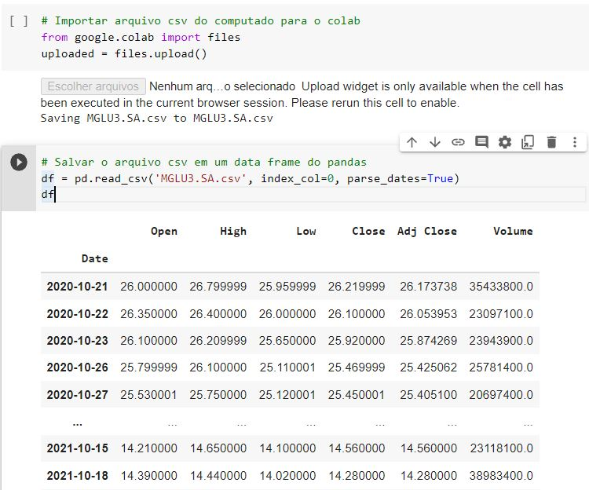

## Gráfico de candle stick interativo

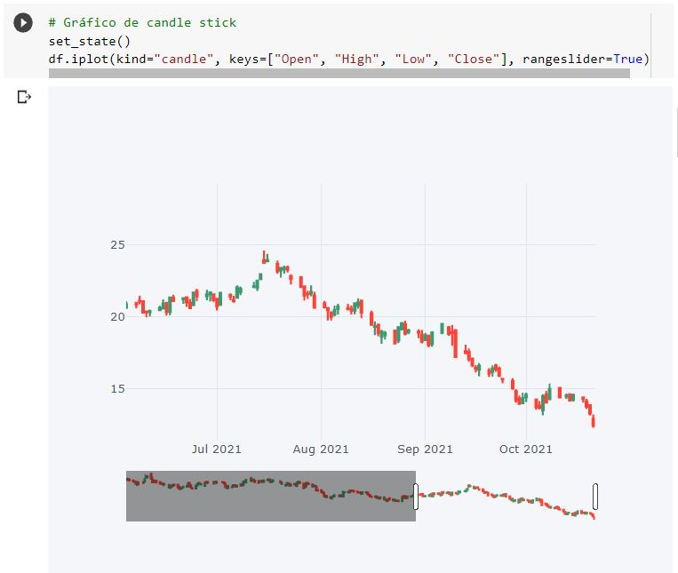

## Gráfico OHLC interativo

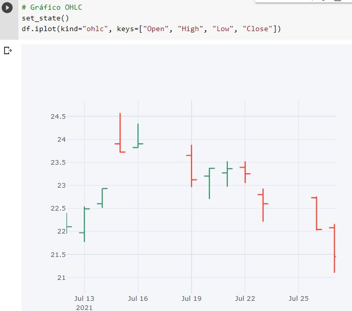

## Resistência e Suporte

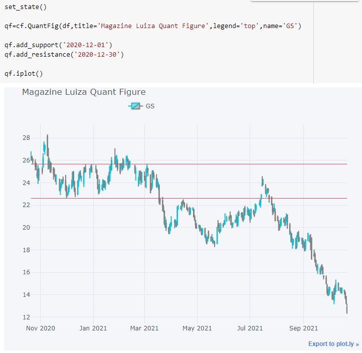

## Usando indicadores técnicos

[figure not shown]

## Usando indicadores técnicos - Exemplo 2

[figure not shown]